# Project1

Yuru Cao

9/24/2019

First, we read in the dataset deliminated by tab, so it would be read into 13 columns after deleting unnecessary columns.

```
##         Date Client.File.Number Client.File.Merge Bus.Tickets..Number.of.
## 1  1/22/2009                212                 0                      NA
## 2  1/29/2009                738                 0                      NA
## 3  1/20/2009               3455                 0                      NA
## 4 11/26/2002               1804             21804                      NA
## 5  12/2/2002               1806             21806                      NA
## 6 10/10/2002               1614             21614                      NA
##     Notes.of.Service Food.Provided.for Food.Pounds Clothing.Items Diapers
## 1                                    3          20              5      NA
## 2                                    4          25             26      12
## 3                                    6          40             39      12
## 4                                    4          NA             NA      NA
## 5                                    3          NA             NA      NA
## 6 financial referral                NA          NA             NA      NA
##   School.Kits Hygiene.Kits Referrals Financial.Support
## 1          NA           NA         1                 0
## 2          NA           NA         1                 0
## 3          NA           NA         1                 0
## 4          NA           NA Baby Love                 0
## 5          NA           NA Baby Love                 0
## 6          NA           NA       DSS                 0
```

#### Data Cleaning

For this project, we will address two questions as follows. In general, we only need to look at five variables: Client.File.Number, Data, Food.Pounds, Food.Provided.for, and Diapers.  
1. Remove the unrelated columns  
2. Mutate Date data into Year.  
3. Filter the year data into 2008~2019.  
4. Mutate the food.per.capita variable

## Problem 1 How average food providing per capital has changed?

#### After reading the dataset, we are curious about how average food providing has changed overtime. Are they increasing with the time? Or do they tend to grow smaller?

Since we only want to see the data grouped by year, we will arrange the date variable into yearly format. We create a new data frame to store the two variables we want to plot. Upon primary inspection, we find out that effective data is only availble from 2008ish. Therefore, we filter the date between 2008~2019. After plotting the data points, we spotted many outliers in Food per capita >75000 which may be caused by the inconsistency of the data. So we remove the outliers and only focus on 0~2000 pounds per capita.

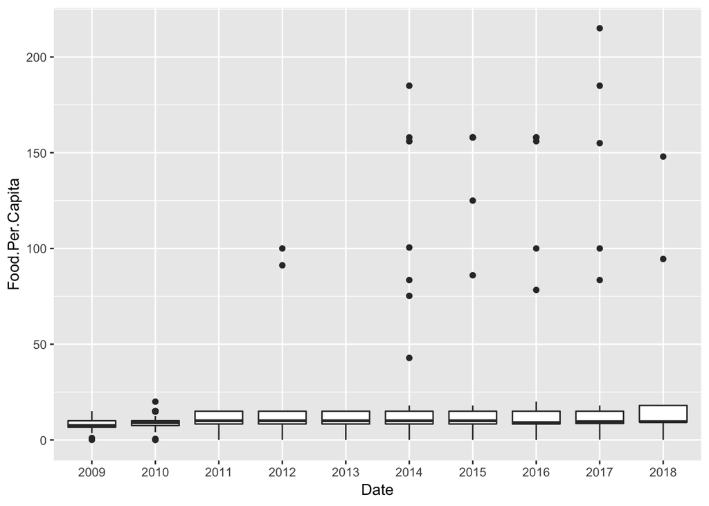

## Problem 2 What’s the relationship between food provide and diapers?

#### Next, we are interested in whether they have certain relationship between food pounds and diapers providings? Is there a hidden pattern between these two?

For data preparation, we find out that there exist some inconsistency in diapers record, so we need to remove the outliers with value larger than thousand. Also, we are not addressing this problem at individual level instead of date level. So we sum up the diapers count and food pounds based on client file ID.

To find out the potential relationship between these two variables, we did a correlation test in Pearson method to identify the result statistically. It turned out that they have a positive relationships(0.58) between food and diaper providing. The p-value is far less than 0.05 so this relationship is significant.

```
##
##  Pearson's product-moment correlation
##
## data:  datarela$Food.Pounds and datarela$Diapers
## t = 13.207, df = 346, p-value < 2.2e-16
## alternative hypothesis: true correlation is not equal to 0
## 95 percent confidence interval:
##  0.5045057 0.6448159
## sample estimates:
##       cor
## 0.5789307
```

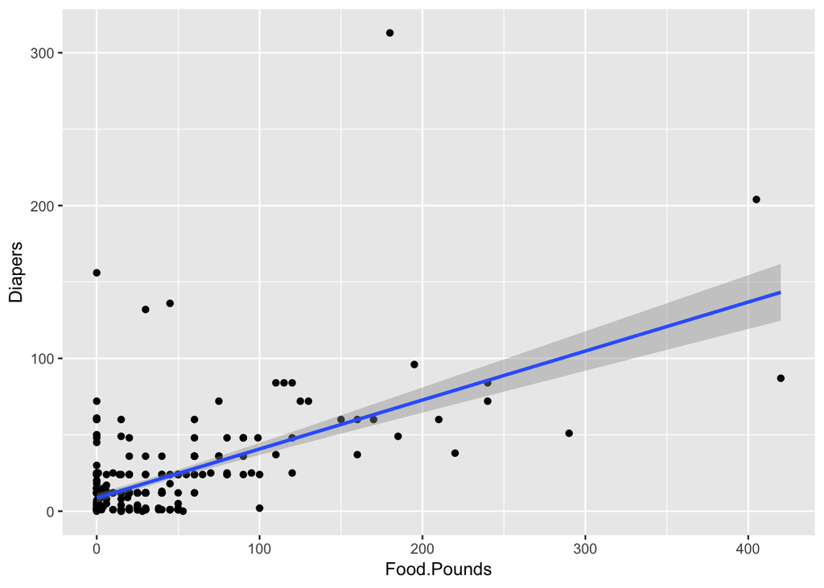

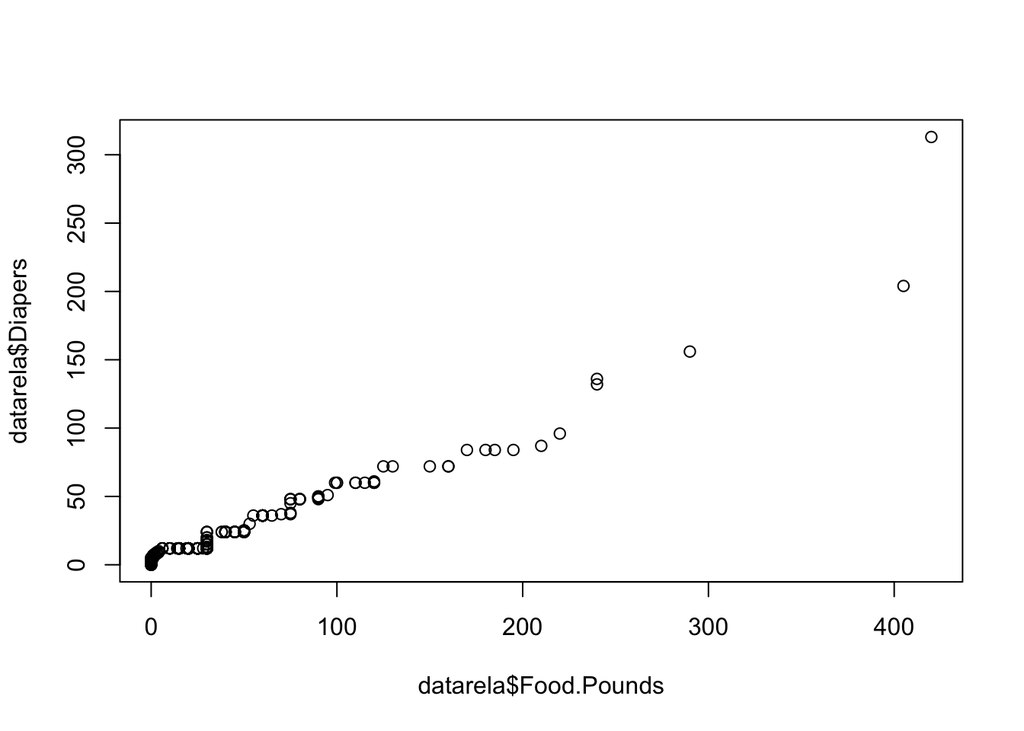